# Open Source Is Good for Business

Jim Gruman

2020-03-24

[figure not shown]

Why Choose Open Source?

Inspired by: > Ben Balter’s [6 motivations for consuming or publishing open source software](https://opensource.com/life/15/12/why-open-source)

> Gordon Shotwell’s [Why I use R](https://blog.shotwell.ca/posts/why_i_use_r/)

> Tina Amirtha’s [Why The R Programming Language Is Good For Business](https://www.fastcompany.com/3030063/why-the-r-programming-language-is-good-for-business)

With many organizations embracing open source software like `Linux` and `R`, it’s becoming increasingly clear that price is not the only advantage. If it were, companies that adopted open source solutions during the Great Recession of 2008 would have switched back to the expensive proprietary stuff as soon as conditions began to be eased, and that’s clearly not the case.

Whether the enterprise is a corporation, a small business, a non-profit, academia, or a government agency, that vast array of open source products is awesome. Software is a critical part of any modern economy. It touches every part of every life in the developed world, and is increasingly transforming everyday life, from womb to grave, everywhere. There are many reasons to consider consuming, publishing, collaborating on, and supporting open source.

One example: With pentabytes of data at hand, enterprises are trying to figure out the best way to understand information about their customers and themselves. But using Excel pivot tables to analyze massive quantities of information is absurd, so in the recent past companies would invest in a commercially available, proprietary, tool like `SAS` to cull business intelligence.

But `SAS` is no match for the open-source tools that pioneering data scientists use in academia, built largely on `R`. The `R` programming language leans more frequently to the cutting edge of data science, giving businesses the latest data analysis tools. And the rapid evolution of `R` and a wide variety of other open source tools is driven in large part by community-driven open source development advantages.

Here are a few of them:

## Microeconomic motivations

**Lower total cost of ownership (TCO):** Between the purchase price of the software itself, on-going support charges, ongoing upgrade expenses and the costs associated with being locked in, proprietary software takes more out of the business than most users probably even realize. And for what? You can get better quality at a fraction of the price. Using open source software yields a lower total cost of ownership when compared to closed source and proprietary alternatives. Adopting open source software generally has a lower up-front cost because the software often comes at no cost or relatively low cost, and shifts the cost center from licensing to customization and implementation. Additional costs like training, maintenance, and support are sunk. You’re going to be paying for both regardless of if the software is open or closed source, the cost often being baked into the license in the case of commercial, off-the-shelf software (COTS). What makes open source unique is that you’re not paying for the right to use the underlying intellectual property.

| Cost | Open source | Proprietary |
| --- | --- | --- |
| Licensing | No | Yes |
| Implementation | Yes | Yes |
| Maintenance | Yes | Yes |
| Support | Yes | Yes |

**Given enough eyeballs, all bugs are shallow** (Linus’s Law): Empirically, open source [tends to produce better quality software than its proprietary or alternative counterparts](https://dwheeler.com/oss_fs_why.html). With closed source software, the only developers that can potentially detect, diagnose, triage, and resolve software bugs are those that happen to be employed by the company that publishes the software (or the arms-length contractor paid to build it). Open source provides three advantages here: first, the opportunity to tap the knowledge of the world’s best developers, not just those on one organization’s payroll. Second, the number of potentially contributing developers and thus the potential knowledge pool is orders of magnitude larger. Finally, open source software gets adapted in variety of use cases, not just the one the publisher originally intended, surfacing bugs and edge cases much more rapidly than traditional QA processes.

**Modern software development practices:** Open source software is more than simply “published” code. You’d be hard-pressed to find an open source project that follows outdated command-and-control development philosophies. By virtue of being distributed and unburdened by technical debt, open source projects all but necessitate modern software development workflows. These workflows are electronic (meaning process is naturally captured and exposed), asynchronous (meaning decisions are time and location agnostic), and lock-free (meaning contributors can rapidly experiment without prior approval). These three workflow characteristics yield more rapid development cycles and more frequent releases without sacrificing quality.

**Open source is the future:** There is no startup today worth it’s venture capital funding without being based, at least in part on open source tools. Open source isn’t a fad. Open source is how modern organizations, and increasingly more traditional organizations, build software. It’s becoming exceedingly challenging to make the argument that five-or-ten years from now the technology landscape is going to be less collaborative and more closed. Even Microsoft, traditionally one of the most stark opponents to open source, has open sourced their primary development framework (along with Apple, Facebook, and Google). Today, the largest names in technology, from IBM, to SAP, to Adobe actively participate in the open source community. It’s inaccurate to say that “open source is the future.” Open source has already won.

[Microsoft Azure Open Source Support 2018](https://dotnettricks.blob.core.windows.net/img/azure/microsoft-azure-open-source-supports.png)

**Patch on your own schedule:** So long as software is written by humans, bugs and security vulnerabilities are inevitable. When a vulnerability is discovered in a proprietary software project, developers have to wait for the workday to begin in the company’s timezone, for meetings to be held, tasks deligated, and code written, all before overhead teams like legal, sales, and marketing have to coordinate how to get the fix into the next regularly-scheduled release. For proprietary software, bugs and vulnerabilities affect the bottom line, and thus there’s a disincentive to make details widely publicized. With open source, not only can leaner, more agile, non-profit-oriented organization move faster, since all have access to the source code, developers can often apply fixes, both large and small, at the developer’s convenience, not at the convenience of the publishing organization’s release cycle.

**Upstream improvements:** When consuming open source software, it’s in your best interest to contribute back. Contributions can be in the form of reporting bugs, or even submitting proposed fixes. Since software is written by humans, it’s highly unlikely to be perfect, and even if so, likely doesn’t satisfy every use case. Rather than forking the project and implementing changes into your own version (closed source), submitting bug reports and improvements upstream, open source allows the consumer to more easily continue to benefit from the subsequent fixes and improvements submitted by others.

**Interoperability:** Open source software is much better at adhering to open standards than proprietary software is. If interoperability with other businesses, computers, and users has a high value, and B2B parties don’t want to be limited by proprietary data formats, open source software is definitely the way to go.

**Auditability:** With closed source software, there is little but the vendor’s claims assuring that they’re keeping the software secure and adhering to standards, for example. It’s basically a leap of faith. The visibility of the code behind open source software, however, means all developers can monitor compliance and be confident.

Finally, **Shifting developers from low-value work to high-value work:** In open source communities we often hear that all the easy problems have already been solved. Blogging, content management, and operating systems are all problems with established (and mainstream) open source solutions, to name a few. While your developers could spend their time reinventing wheels that the open source community have already perfected, it’s far preferable to use the worlds best wheel, especially when that wheel comes at no cost to you. This frees developers up to work on yet-unsolved challenges, the types of challenges that are unique to and add value to your organization’s mission. Why not stand on the shoulders of technology giants?

Taking the matter of software updates further, when a proprietary application stops being developed, it’s not uncommon for its updates to stop as well. With open source software, interested parties can fork or adopt the code for a given application and continue releasing updates.

Another significant reason to use open source software is to prevent vendor lock-in. For example, let’s say the company is using a proprietary publishing application. One day, the company releases a new version and explains that going forward, older file versions for the application won’t be supported by the new version. This means if you have an older version of one PC, and the latest version on the second PC, they can’t exchange files due to compatibility issues. The company’s motivation is for you to run the latest version of the software on BOTH computers.

Had the company been using open source software, the file format would have either remained unchanged between software versions or the ability to import the older files would have been provided. A great example of this is found with Microsoft Office documents. Even though today’s LibreOffice has fair docx support, it’s still known to cause formatting and other compatibility issues due to Microsoft’s document standard. With LibreOffice’s support of the ODF format, Word 2007 and higher all support the file format just fine. After all, it’s an open document standard. So adopting it into an application is transparent. The same can’t be said for docx.

Consider also that companies rely on software support. Getting proprietary software support means getting it from the original software vendor. If that company goes under or stops supporting the application, you’re out of luck. But even if they still support your software, perhaps you have had lousy experience with the software provider’s customer service. And why should they care – if you want support, you’re forced to come to them.

In the open source world, especially in terms of enterprise applications, there are ample open source support companies willing to help. Many open source projects have commercial support available. And if a project doesn’t, often you can find a separate company that provides paid support for most open source applications. Many times these separate companies are part of a certification process for that particular open source software. Examples include Linux certification to LibreOffice certification.

GitHub Cofounder Tom Preston-Werner lays out some additional arguments in his 2011 post [Open Source (Almost) Everything](https://tom.preston-werner.com/2011/11/22/open-source-everything.html)

**Force multiplier:** Open source is a force multiplier for developers. This happens in three ways: First, when communities form around shared challenges, the diversity of ideas that naturally emerges surfaces better solutions than if the marketplace of ideas was limited to just your organization, meaning developers are working smarter. Second, exposing the problem space to other interested organizations provides additional human capital to tackle the challenge, meaning the solution has more developer hours thrown at it, at no additional cost. Finally, “more users means more use cases being explored, which means more robust code.”

**Modular:** Open source projects tend to be more modularly architected, improving both the flexibility, and the robustness of the code. When building software for a single use case, the developer is able to take some technical short cuts. The problem comes when the enterprise would like to use that software in a different use case, or when requirements change. Open source, by its nature, is built for a variety of use cases, environments, and users. This means more options, and a tendency to encourage more modularity, resulting in greater flexibility and lower customization costs in the long run. Put another way, open source necessitates cleaner, more maintainable code. “Even internal code should pretend to be open source code”.

The [Amazon API Mandate](https://www.cio.com/article/3218667/have-you-had-your-bezos-moment-what-you-can-learn-from-amazon.html) recognizes similar principles to be agile and drive innovation by requiring developers to scale technology assets with APIs–externalizable services–so the broader organization could independently reuse and leverage code assets to drive business outcomes through other use cases. [Amazon continues to be a large contributor to open source communities](https://aws.amazon.com/opensource).

**Reduce duplication of effort:** You should focus on your core competency. What makes you unique or gives you an advantage? Everything else is the work everyone else is also doing: or put another way, the work you need to do so that you can do the work that you want to do. It doesn’t have to be that way. Open source reduces duplication of efforts, both within an organization and across organizations, by allowing for individual components to be shared. Coca-Cola’s secret sauce is the formula for its syrup, not its ability publish blog posts or post press releases. Using an open source CMS, or sharing their built-in-house blog components with the world, doesn’t make Pepsi taste any better. “Less duplication means more work towards things that matter.”

**Great advertising:** Maintainers of successful open source projects are often seen as industry leaders, providing themselves with the ability to shape the conversation around particular software problems and associating their brand with the preferred solution. `CNHIndustrial`, for example, is a founding member of the [OATSCenter](https://oatscenter.org/) and `AirBNB` is a primary developer of Apache Airflow.

**Attract talent:** Developers want to work on yet-unsolved problems. Open source allows you to showcase to the developer community, the interesting challenges you face, and how you think about solving them. Open source developers can casually contribute to projects, to learn how you work, and what it’s like developing software for a particular set of challenges. If they like what they see, there’s a much better chance that they’ll apply for a job, than if your organization was a black box when it comes to what it’s like to work there. “Smart developers like to hang out with smart code.”

**Best technical interview possible:** Technical interviews traditionally involve working on a simulated problem that can be tackled in a set amount of time with little additional context. Such simulations, by definition, aren’t real world use cases, nor do they show what working with an applicant would be like. Open source provides visibility into both how a candidate solves problems, and how they work with others. You can hire much more confidently if, for the past six months, the candidate has been contributing to the project you want them work on, and you like their work. “[T]he best technical interview possible is the one you don’t have to do because the candidate is already kicking ass on one of your open source projects.”

[figure not shown]

IMAGE: FLICKR USER: _SARCHI

## Macroeconomic motivations

By combining and augmenting parallel or related efforts, open source makes a society more efficient at producing higher quality software.

**Efficiency:** Many of the microeconomic arguments above, in the aggregate, have a macroeconomic impact. When firms work more efficiently, the economy produces more (and better) software, software that can in turn, improve lives. If you believe that all the easy problems have already been solved, then on a macroeconomic level, open source allows you to move firms from lower-level work to higher level, yet-unsolved challenges. The results of this higher level work tends to be disruptive, rather than iterative, creating the churn that invigorates the economy. If every technology company must devote a few years of R&D solving the same 5-10 problems, that delays (or at the very least shifts capital from) the company’s ability to be productive and produce technology that’s valuable to society, not to mention, it raises the barrier for new market entrants to offer alternatives to established firms.

**Stand on the shoulders of giants:** Today, innovative technology, the type of technology that improves quality of life, isn’t created in a vacuum. The full value in data is only realized when it can be integrated from multiple, context-rich sources in ways that adhere to trust requirements of its owners. Even closed source technology, from the cell phone in your pocket to the car you drive to the Fortune 500 company that produced them, rely heavily on open source. Just take a look at your phone’s “settings -> about” page. Open source allows developers to take already-solved problems as a given, to rely on the knowledge of experts beyond their own domain of expertise, and unlocks their potential to create new inventions otherwise not possible.

**Fuel the marketplace of ideas:** Software is nothing more than technical knowledge. There was once a time when alchemists would withhold the results of their work, claiming their discoveries as proprietary. Each had to learn the hard way the result on the human body of drinking lead. When those alchemists began sharing their work, we began calling them scientists, and the scientific revolution was born. The same is true of computer software. Two developers working individually may come up with two solutions to a given problem, but through dialog and collaboration, each bringing their own knowledge and experience, may discover three, five, or ten solutions to the same, and society is better as a result.

At `Facebook`, the data science team’s data visualizations in `R` give it the best overview of what kind of data it is dealing with. The data can range from something like News Feed numbers to correlations with the amount of connections a user has. “Generally, we use R to move fast when we get a new data set,” says Solomon Messing, data scientist at `Facebook`. “With R, we don’t need to develop custom tools or write a bunch of code. Instead, we can just go about cleaning and exploring the data.” Messing and the other `Facebook` data scientists regularly use open-source `R` packages from Hadley Wickham, chief scientist at `RStudio`. Wickham’s packages, like ggplot2, dplyr, plyr, and reshape, allow the team to explore new data through custom visualizations. The `Facebook` data science team uses `R` so ardently to visualize data that it even created a [MOOC](https://www.udacity.com/course/data-analysis-with-r--ud651) that teaches students what it knows.

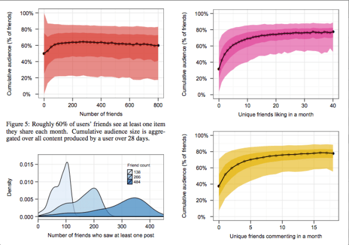

Visualizations from Messing’s colleagues at Facebook, done in collaboration with Stanford University’s HCI Group

## Moral motivations

The formal name for open source is free/libre open source software. As such, open source motivations have a strong moral component. The most notable example, the Apache Software Foundation, has for over 20 years embraced their original goals of transparent, community-driven collaboration in a vendor-neutral environment that is accessible to all.

A core tenet of The Apache Way is “Community Over Code”, which encapsulates their deep belief that a healthy community is a far higher priority than good code. A strong community can always rectify a problem with the code, whereas an unhealthy community will likely struggle to maintain a codebase in a sustainable manner. Healthy communities ensure the Foundation has the stability to thrive for the next 20 years and beyond. Apache projects do not have the problem of scaling that others, who focus only on the legal frameworks of Open Source, suffer from. If you look around at projects that have grown up alongside the Apache projects, you will see a similar focus on scaling the governance model. This is no accident.

Free as in speech, not as in beer: Open source software is not without cost. When open source software is called “free,” it is a reference to the rights the software consumers receive, not the cost they must pay. Adobe’s Flash player, for example, is free software in the economic sense, but is still at the core of proprietary (non-free) software (and formats). Specifically, free software refers to four core freedoms: the freedom to run the software, the freedom to study and modify the software, the freedom to redistribute the software, and the freedom to distribute your modifications. Free software places power back in the hands of users and ensures users control the software they use, not the other way around.

**Obligation to give back:** Open source is the give-a-penny-take-a-penny jar of software. If you consume open source, be it a server, a desktop publishing application, or a software library, you have an obligation to give back to the community. After all, without the contribution of others, the micro- and macroeconomic motivations would no longer hold true, and open source as we know it would cease to exist. This is the Golden Rule, or in traditional philosophical terms, a categorial imperitive.

**Governments** should give what they’ve developed to the people who pay for their development: If the development costs are paid by a government, then there’s an additional argument for giving back. Governments take money (taxes) to perform services for their populace. For example, the US federal government was established through its Constitution by we the people to perform a number of important tasks. If the populace (we the people) are paying for the development of software, it stands to reason that we should receive what we paid to develop, including the software we paid to develop.

**Teaching the next generation:** Many of the industry’s most prominent engineers today cut their teeth by learning from open source. When software’s underlying code is made available for inspection, consumers can learn how their favorite software works and computer science courses can analyze how the industry’s cutting edge technology is built. This goes a long way to train the next generation of software engineers (who without open source would be left guessing at the inner-workings of prior iterations).

## Transparency motivations

Open source allows for greater transparency of process, whether that’s the transparency necessary to check a government action or the quasi-governmental function of a private company’s software.

**Showing your work:** As the government increasingly relies on technology to regulate industries and deliver citizen services, being able to see the underlying algorithms and processes are essential to checking the government’s work. If a closed-source software package is used to calculate my taxes or allocate broadcast frequencies, how do I know that the process, our process, is fair and accurate? Whereas human processes can’t be copyrighted, when close source, such processes become a black box, minimizing the potential for a citizen counterbalance.

**Positions of public trust:** As the software produced by private corporations are increasingly placed in positions of public trust, the transparency obligation extends into the private sector as well. Did the voting machine accurately count my vote? When given a lose-lose choice, does the self-driving car conform to community norms? For example, if a closed-source software package is used to compare DNA at a crime scene, unlike a medical expert who can be cross examined, that proprietary algorithm is shielded from scrutiny by copyright (or patent) law. Open source, at least partial open source of particular components, will become essential as private companies automate quasi-government functions.

## Participatory motivations

Open source affords software stakeholders, both technical and non-technical, the opportunity to shape any given software development project.

**Direct democracy:** True direct democracy (where every citizen votes on every issue) isn’t tenable given the size of most democracies. Nor have citizen been able to participate directly in most issues, due to technical constraints. Open source changes that by allowing software stakeholders to participate directly in the software development process (as software is increasingly relied on to codify regulatory and service-delivery preferences and norms). Think the process of buying health care is confusing? Open an issue. Believe the government should use more open source, submit a pull request. The White House is already doing this for many IT-centric policies like the Digital Services Playbook, HTTPS, and open data policies.

Gordon Shotwell explains in the [Glory of CRAN](https://blog.shotwell.ca/posts/why_i_use_r/) how the R-Project Consortium package repository [CRAN](https://cran.r-project.org/) has created a strong consensus on how to package and distribute code extensions, which means that nine times out of ten a package will install and run with no user configuration. This feature is important because we want code to be useable and installable by people who do not think of themselves as programmers and do not have any tolerance for the command line. His goal for all the products he develops is that they are installable and runnable with a single user action, and that action cannot take place in the terminal. CRAN moves a lot of the setup and configuration pain from the end user to the package maintainer, and while this probably slows down development and release of packages, it vastly improves the user experience of the average user.

**Customer feedback:** Open source empowers consumers to have a combined, powerful voice in the private sector development process. Think of it like Yelp for software. Without Yelp, a restaurants is free to upset a single customer. At most, that dissatisfied patrons could dissuadee 5-10 other potential patrons. In a post-Yelp world, customers read the reviews of strangers before they choose where to go. Open source amplifies the voice of software consumers within the consumer-publisher relationship. Not to mention, the feedback the private company receives can go towards better informing product decisions and improve the overall product. Open source gives companies a direct line to their most passionate customers.

## Personal motivations

Whether you are a developer or an aspiring developer, open source can provide an inexpensive onramp to a path for personal growth within the software development community.

**Learn to code:** Open source is a great way to learn how to code. Want to know how your favorite website works? Clicking “view source” in your web browser can go a long way to point you in the right direction. You can read the documentation of the software that powers it, and potentially even stand up your own clone. Want to learn more? Join the local meetup for the framework or language. Better still, submit a pull request to the project to fix a small bug or add a new feature. While there are certainly time and opportunity costs involved, all of this comes without any direct cost to the aspiring developer, at least not in terms of software, and is infinitely more inclusive than doing the same within a proprietary community, especially as an outsider. There’s a reason nearly every coding school today outside of traditional academia teaches open source.

**It’s fun:** According to Wikipedia, open source is a hobby. In fact, open source has traditionally had the reputation of being the product of hobbyists (although I’d argue that’s less true today). Open source is fun. If you’re a hacker it provides an endless set of ever-changing set of Rubix cubes for you to solve on weekends. Just as puzzles (both crossword and jigsaw) provide bite-sized intellectual escapes, the order and symmetry of open source can often be a rock garden of code (especially for those for which football is an embarrassing non-starter).

There are likely other reasons to prefer consuming, publishing, collaborating on, and supporting open source beyond those listed here. Whatever the rationale, it’s clear open source isn’t the next big thing. Open source is already here.

### Did you find this page helpful? Consider sharing it 🙌